# Week 3 Skill Builders

Your Names

2021-04-22

## Assignment

### Chapter 6 questions

6M1. Modify the DAG on page 186 to include the variable V, an unobserved cause of C and Y: $C \leftarrow V \rightarrow Y$. Reanalyze the DAG. How many paths connect X to Y? Which must be closed? Which variables should you condition on now?

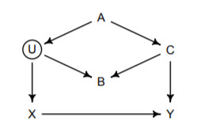

6M2. Sometimes, in order to avoid multicollinearity, people inspect pairwise correlations among predictors before including them in a model. This is a bad procedure, because what matters is the conditional association, not the association before the variables are included in the model. To highlight this, consider the DAG $X \rightarrow Z \rightarrow Y$. Simulate data from this DAG so that the correlation between X and Z is very large. Then include both in a model to predict $Y$. Do you observe any multicollinearity? Why or why not? What is different from the legs example in the chapter?

6M3. Learning to analyze DAGs requires practice. For each of the four DAGs below, state which variables, if any, you must adjust for (condition on) to estimate the total causal influence of $X$ on $Y$.

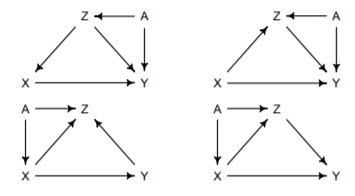

All three problems below are based on the same data. The data in data(foxes) are 116 foxes from 30 different urban groups in England. These foxes are like street gangs. Group size varies from 2 to 8 individuals. Each group maintains its own urban territory. Some territories are larger than others. The area variable encodes this information. Some territories also have more avgfood than others. We want to model the weight of each fox. For the problems below, assume the following DAG:

```r
library(dagitty)
dag_6H3 <- dagitty("dag{
  avgfood -> weight <- groupsize
  avgfood -> groupsize
  area -> avgfood
  }"
)
coordinates(dag_6H3) <- list(
  x=c(avgfood=0,groupsize=2,weight=1,area=0),
  y=c(avgfood=1,groupsize=1,weight=0,area=2)
  )
drawdag(dag_6H3)
```

[output not shown]

6H3. Use a model to infer the total causal influence of area on weight. Would increasing the area available to each fox make it heavier (healthier)? You might want to standardize the variables. Regardless, use prior predictive simulation to show that your model’s prior predictions stay within the possible outcome range.

6H4. Now infer the causal impact of adding food to a territory. Would this make foxes heavier? Which covariates do you need to adjust for to estimate the total causal influence of food?

6H5. Now infer the causal impact of group size. Which covariates do you need to adjust for? Looking at the posterior distribution of the resulting model, what do you think explains these data? That is, can you explain the estimates for all three problems? How do they go together?

### Chapter 7 questions

7H1. In 2007, The Wall Street Journal published an editorial (“We’re Number One, Alas”) with a graph of corporate tax rates in 29 countries plotted against tax revenue. A badly fit curve was drawn in, seemingly by hand, to make the argument that the relationship between tax rate and tax revenue increases and then declines, such that higher tax rates can actually produce less tax revenue. I want you to actually fit a curve to these data, found in `data(Laffer)`. Consider models that use tax rate to predict tax revenue. Compare, using WAIC or PSIS, a straight-line model to any curved models you like. What do you conclude about the relationship between tax rate and tax revenue?

7H2. Consider three fictional Polynesian islands. On each there is a Royal Ornithologist charged by the king with surveying the bird population. They have each found the following proportions of 5 important bird species:

```r
library(kableExtra)
dt <- mtcars[1:5, 1:4]
dt <- tibble(
  Island_1 = c( 0.2, 0.2, 0.2, 0.2, 0.2 ),
  Island_2 = c( 0.8, 0.1, 0.05, 0.025, 0.025 ),
  Island_3 = c( 0.05, 0.15, 0.7, 0.05, 0.05)
)
rownames(dt) <- c( "Species A", "Species B", "Species C", "Species D", "Species E" )
colnames(dt) <- c( "Island 1", "Island 2", "Island 3")
# HTML table
kbl(dt, caption = "Birds of a Feather") %>%
  kable_styling(bootstrap_options = "striped",
                full_width = F)
```

Birds of a Feather

|  | Island 1 | Island 2 | Island 3 |
| --- | --- | --- | --- |
| Species A | 0.2 | 0.800 | 0.05 |
| Species B | 0.2 | 0.100 | 0.15 |
| Species C | 0.2 | 0.050 | 0.70 |
| Species D | 0.2 | 0.025 | 0.05 |
| Species E | 0.2 | 0.025 | 0.05 |

- What does each column add up to?

This problem has two parts. It is not computationally complicated. But it is conceptually tricky.

- First, compute the entropy of each island’s bird distribution. Interpret these entropy values.[^1]
- Second, use each island’s bird distribution to predict the other two. This means to compute the KL divergence of each island from the others, treating each island as if it were a statistical model of the other islands. You should end up with 6 different KL divergence values.

Which island predicts the others best? Why?

7H5. Revisit the urban fox data, `data(foxes)`, from the previous chapter’s practice problems. Use WAIC or PSIS based model comparison on five different models, each using weight as the outcome, and containing these sets of predictor variables:

1. avgfood + groupsize + area
2. avgfood + groupsize
3. groupsize + area
4. avgfood
5. area

Can you explain the relative differences in WAIC scores, using the fox DAG from the previous chapter? Be sure to pay attention to the standard error of the score differences (dSE).

## Chapter 6 Solutions

### 6M1: How many roads can we walk down?

From p. 186 in the text, the DAG below contains an exposure of interest X, an outcome of interest Y, an unobserved variable U, and three observed covariates (A, B, and C) that are somehow involved with X and Y.

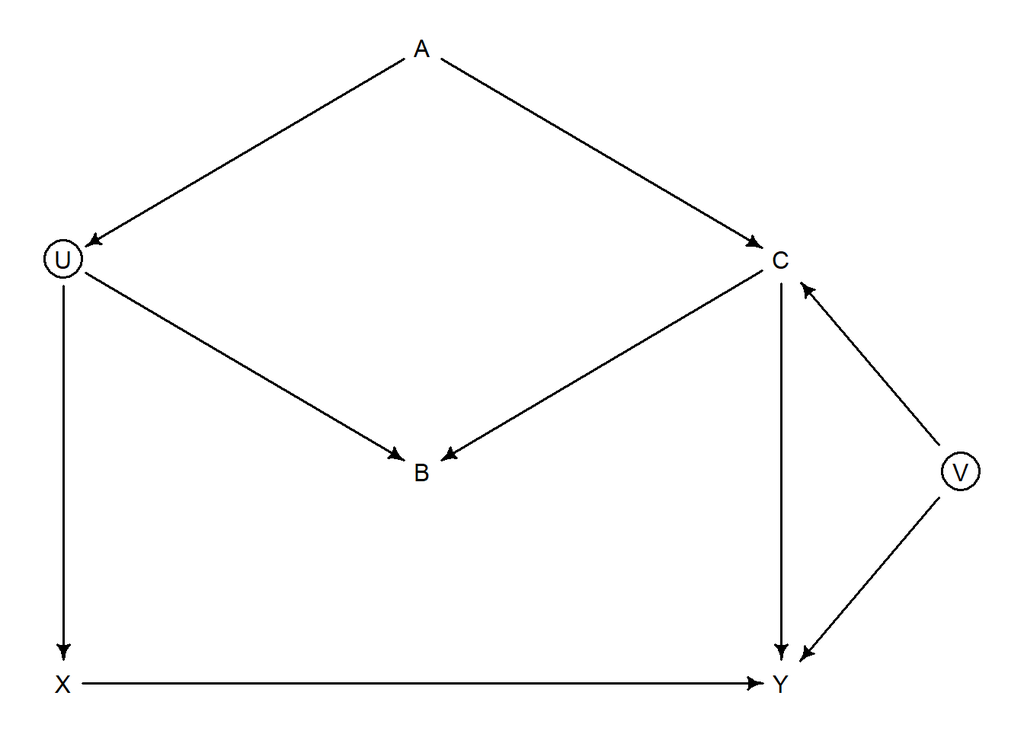

```r
library(dagitty)
dag_6M1_UV <- dagitty("dag{
  U [unobserved]
  V [unobserved]
  X -> Y
  X <- U -> B <- C -> Y
  U <- A -> C
  C <- V -> Y }")
coordinates(dag_6M1_UV) <- list(
  x=c(X=0,Y=2,U=0,A=1,B=1,C=2,V=2.5),
  y=c(X=2,Y=2,U=1,A=0.5,B=1.5,C=1,V=1.5)
  )
drawdag(dag_6M1_UV)
```

This get’s the message across: an easy to plot thought experiment on a chalkboard or your living room wall. For the moment forget we posit the existence of an unobserved $V$; instead we focus on unobserved variate $U$. We will soon introduce $V$.

In practical work, the DAG step is often run over, several times, forward and backward. Analysts, who code faster than they think, avoid, or are even unaware, of this most critical of modeling steps. They will dive head first into the concrete of data, often from a great height. The DAG forces us to take a stab at what might be the pathways of inference in answering the question: what can we expect of $Y$? Better yet, deviations from $Y$ can be explained by what variates? Which explanatory, predictive, variates are most important? Do we need them all? Do we need different ones? The spanner in the works is of course $U$ (or, puns intended: YOU:) ), and soon $V$.

We are interested in the $X \rightarrow Y$ path, which depicts the causal effect of $X$ on $Y$. Which of the observed covariates do we need to add to the model, in order to correctly infer it?

To figure this out, we look for backdoor paths. Aside from the direct path, there is first the causal path from $X$ to $Y$. Also there are two other paths from $X$ to $Y$:

$$\begin{align}
(1) X &\rightarrow Y, \,\,\,\, \text{(the causal path)} \\
(2) X &\leftarrow U \leftarrow A \rightarrow C \rightarrow Y \\
(3) X &\leftarrow U \rightarrow B \leftarrow C \rightarrow Y
\end{align}$$

Paths 2 and 3 are both backdoor paths that could confound inference. Thus we ask which of these paths is open. If a backdoor path is open, then we must close it. If a backdoor path is closed already, then we must not accidentally open it and create a new confounding influence. Either $A$ or $C$ will shut the backdoor. This the answer given by `adjustmentSets()`.

```r
library(dagitty)
dag_6M1_U <- dagitty( "dag {
U [unobserved]
X -> Y
X <- U <- A -> C -> Y
U -> B <- C
}")
adjustmentSets( dag_6M1_U , exposure="X" , outcome="Y" )
```

```
## { C }
## { A }
```

Conditioning on either $C$ or $A$ would suffice. Conditioning on $C$ is the better idea, from the perspective of efficiency, since it could also help with the precision of the estimate of $X \rightarrow Y$. So much from the text.

Here is a DAG that includes the variable $V$, an unobserved cause of $C$ and $Y$ such that $C \leftarrow V \rightarrow Y$.

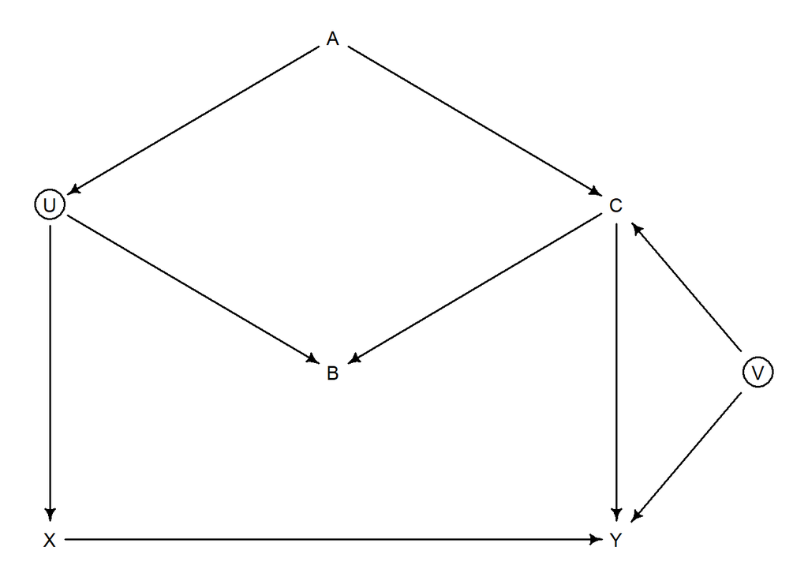

```r
library(dagitty)
dag_6M1_UV <- dagitty("dag{
  U [unobserved]
  V [unobserved]
  X -> Y
  X <- U -> B <- C -> Y
  U <- A -> C
  C <- V -> Y }")
coordinates(dag_6M1_UV) <- list(
  x=c(X=0,Y=2,U=0,A=1,B=1,C=2,V=2.5),
  y=c(X=2,Y=2,U=1,A=0.5,B=1.5,C=1,V=1.5)
  )
drawdag(dag_6M1_UV)
```

Now there are 5 paths connecting $X$ and $Y$:

$$\begin{align}
(1) X &\rightarrow Y \text{(the causal path)} \\
(2) X &\leftarrow U \rightarrow B \leftarrow C \rightarrow Y \\
(3) X &\leftarrow U \rightarrow B \leftarrow C \leftarrow V \rightarrow Y \\
(4) X &\leftarrow U \leftarrow A \rightarrow C \rightarrow Y \\
(5) X &\leftarrow U \leftarrow A \rightarrow C \leftarrow V \rightarrow Y
\end{align}$$

We want to leave path 1 open and make sure all of the others are closed, because they are non-causal paths that will otherwise confound inference. Let’s find the colliders: $B$ and $C$ first. As before with just $U$, all the paths through $B$ are already closed, since $B$ is a collider (*Why?*). So we don’t condition on $B$.

In a similar way, the new paths through both $A$ and $V$ are closed, because $C$ is a collider on those paths. So it will be enough to condition just on $A$ to close all non-causal paths.

Let’s can check this reasoning using `dagitty`:

```r
adjustmentSets( dag_6M1_UV , exposure="X" , outcome="Y" )
```

```
## { A }
```

A question (or two):

- Note that in the chapter, where $V$ is absent, it is also fine to condition on $C$. That is no longer the case, again explain why.
- What is the role of the collider?

Another question (or two):

- What is a DAG good for?
- When don’t we need a DAG?

### 6M2 – Rock ’em sock ’em

Mathematically, an example of multicollinearity effectively means we cannot solve a simultaneous equation. that is because the determinant of a coefficient matrix is zero. Here is perfectly correlated set of data. The two columns in this matrix are exactly the same. In general, one column is linearly dependent on another.

```r
A <- matrix( c(2, 3), nrow = 2, ncol = 2)
b <- matrix( c(4, 5), nrow =2, ncol = 1)
# solve Ax = b for x = inverse(A)b
inverse_A <- solve(A)
```

If you were to run this code, you would get back this error:

> Error in solve.default(A) : Lapack routine dgesv: system is exactly singular: U[2,2] = 0

This exactly correlated set of columns in A will not solve because it is singular. That means that we cannot distinguish between the two columns. It is as if there is only one column in A.

Now for a demonstration of noisy, that is, partially correlated data. To simulate collinear data:

```r
N <- 1000
X <- rnorm(N)
Z <- rnorm(N,X,0.1)
Y <- rnorm(N,Z)
cor(X,Z)
```

```
## [1] 0.994117
```

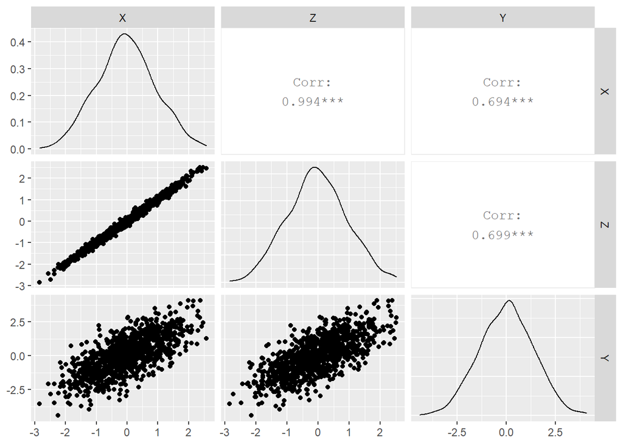

```r
XZY <- tibble( X = X, Z = Z, Y = Y)
XZY %>%
  ggpairs()
```

How correlated? Are X and Z the same variable or different variables? If the same why use both?

Let’s regress:

```r
m_6M2 <- quap(
  alist(
    Y ~ dnorm( mu , sigma ),
    mu <- a + bX*X + bZ*Z,
    c(a,bX,bZ) ~ dnorm(0,1),
    sigma ~ dexp(1)
) , data=list(X=X,Y=Y,Z=Z) )
precis( m_6M2 )
```

```
##             mean         sd         5.5%      94.5%
## a     0.04323885 0.03119465 -0.006616229 0.09309393
## bX    0.03114666 0.27921446 -0.415091977 0.47738530
## bZ    0.97671148 0.27698940  0.534028932 1.41939404
## sigma 0.98592074 0.02203101  0.950710933 1.02113055
```

The standard deviations are larger than we might expect, for such a large sample. But the model has no trouble finding the truth here.

**Bottom line:** We must interpret multicollinearity both in the context of data, but more importantly in the construction of a model. We choose the data to put into the model. This pathological condition is not a property of the data alone. The model and the modeler have some culpability as well.

### 6M3 – Paths of least resistance?

In each case, the procedure is the same:

- List all paths between X and Y
- Identify open non-causal paths are open and
- Hunt for variables to close the open non-causal paths.

We’ll consider each of these panes in turn:

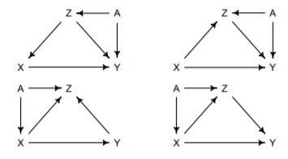

- *Top left.* There are three paths between X and Y:

$$\begin{align}
(1) X &\rightarrow Y, \\
(2) X &\leftarrow Z \rightarrow Y, \\
(3) X &\leftarrow Z \leftarrow A \rightarrow Y.
\end{align}$$

Both (2) and (3) are open, non-causal paths. Conditioning on Z is sufficient to close both.

*Top right.* Again three paths:

$$\begin{align}
(1) X &\rightarrow Y, \\
(2) X &\rightarrow Z \rightarrow Y, \\
(3) X &\rightarrow Z \leftarrow A \rightarrow Y.
\end{align}$$

Paths (1) and (2) are both causal. We want both open. Path (3) is non-causal, but it is also closed already because Z is a collider on that path.

Only path (1) is causal. The other paths are both closed, because both contain a collider at Z. Conditioning on Z would be a disaster.

Paths (1) and (2) are causal. Path (3) is an open backdoor path. To close it, we must condition on A or Z, but if condition on Z, that would close a causal path.

### 6H3 – Weighty matters

Here is the DAG again.

```r
library(dagitty)
dag_6H3 <- dagitty("dag{
  avgfood -> weight <- groupsize
  avgfood -> groupsize
  area -> avgfood
  }"
)
coordinates(dag_6H3) <- list(
  x=c(avgfood=0,groupsize=2,weight=1,area=0),
  y=c(avgfood=1,groupsize=1,weight=0,area=2)
  )
drawdag(dag_6H3)
```

[output not shown]

Let’s start the interrogation.

- If there are no back-door paths from area to weight, what should we include?

Here is a model using standardized versions of the variables and those standardized priors from the book:

```r
library(rethinking)
data(foxes)
d <- foxes
d$W <- standardize(d$weight)
d$A <- standardize(d$area)
m1 <- quap(
alist(
  W ~ dnorm( mu , sigma ),
  mu <- a + bA*A,
  a ~ dnorm(0,0.2),
  bA ~ dnorm(0,0.5),
  sigma ~ dexp(1)
), data=d )
precis(m1)
```

```
##               mean         sd       5.5%     94.5%
## a     9.330365e-10 0.08360867 -0.1336228 0.1336228
## bA    1.883359e-02 0.09089583 -0.1264355 0.1641027
## sigma 9.912661e-01 0.06466649  0.8879166 1.0946157
```

Some followup questions, of course.

- What is the influence of territory size?

### 6H4 - Free lunches for fox gangs?

To infer the causal influence of avgfood on weight, we need to close any back-door paths. There are no back-door paths in the DAG. So again, we can just use a model with a single predictor.

- What happens if we include groupsize, to block the indirect path?
- But how about the effect of adding food?

```r
d$F <- standardize(d$avgfood)
m2 <- quap(
alist(
  W ~ dnorm( mu , sigma ),
  mu <- a + bF*F,
  a ~ dnorm(0,0.2),
  bF ~ dnorm(0,0.5),
  sigma ~ dexp(1)
), data=d )
precis(m2)
```

```
##                mean         sd       5.5%     94.5%
## a      1.036027e-06 0.08360493 -0.1336158 0.1336179
## bF    -2.421062e-02 0.09089107 -0.1694721 0.1210509
## sigma  9.912123e-01 0.06466970  0.8878576 1.0945669
```

More questions.

- What is the effect of adding food?
- Does this have anything to do with area?

### 6H5 – Back doors

```r
d$G <- standardize(d$groupsize)
m3 <- quap(
alist(
  W ~ dnorm( mu , sigma ),
  mu <- a + bA*A + bG*G,
  a ~ dnorm(0,0.2),
  c(bA,bG) ~ dnorm(0,0.5),
  sigma ~ dexp(1)
), data=d )
precis(m3)
```

```
##                mean         sd       5.5%      94.5%
## a      0.0002130256 0.08012127 -0.1278362  0.1282623
## bA     0.4057554666 0.14534492  0.1734662  0.6380447
## bG    -0.4817451021 0.14535620 -0.7140524 -0.2494378
## sigma  0.9418086569 0.06157182  0.8434050  1.0402123
```

Some questions:

- What is the relationship between group size and weight? What would this relationship control for?
- What is the relationship between food and weight, and what does this relationship control for?
- What is the causal influence of group size? And the causal influence of food?
- What masking effect is at work here and why? Hint: review the milk example.
- Look up the ecological behavior known as an ideal free distribution. How might this at work in the gang of foxes?

## Chapter 7 Solutions

### 7H1 – Arthur Laffer

Let’s explore the data first.

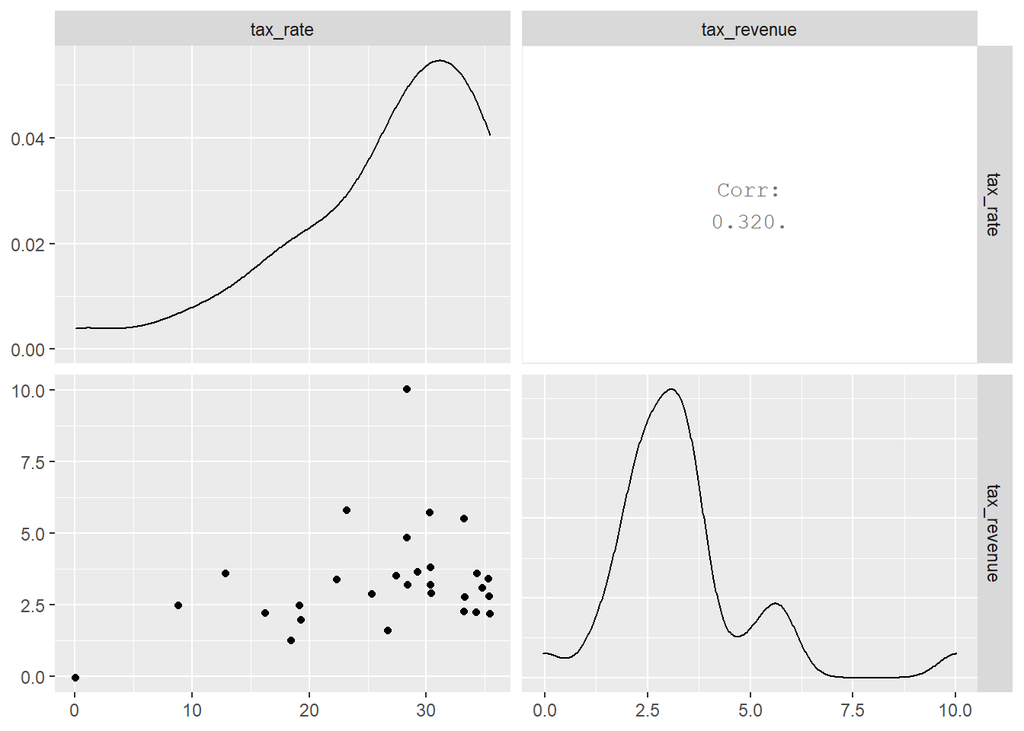

```r
library(GGally)
library(rethinking)
data(Laffer)
d <- Laffer
ggpairs( d )
```

Let’s attempt polynomial fits of degree 1 (the so-called linear model), degree 2 (affectionately known as a quadratic fit), and degree 3 (cubic, almost related to Picasso).

```r
d$T <- standardize( d$tax_rate )
d$R <- standardize( d$tax_revenue )
# linear model
m7H1_lin <- quap(
  alist(
    R ~ dnorm( mu , sigma ),
    mu <- a + b*T,
    a ~ dnorm( 0 , 0.2 ),
    b ~ dnorm( 0 , 0.5 ),
    sigma ~ dexp(1)
  ) , data=d )
precis(m7H1_lin, digits = 4)
```

```
##                mean        sd        5.5%     94.5%
## a     -8.814769e-08 0.1296744 -0.20724489 0.2072447
## b      2.854372e-01 0.1639682  0.02338435 0.5474901
## sigma  9.172425e-01 0.1178158  0.72895001 1.1055349
```

```r
# quadratic model
m7H1_quad <- quap(
  alist(
    R ~ dnorm( mu , sigma ),
    mu <- a + b1*T + b2*T^2,
    a ~ dnorm( 0 , 0.2 ),
    c(b1,b2) ~ dnorm( 0 , 0.5 ),
    sigma ~ dexp(1)
  ) , data=d )
precis(m7H1_quad, digits = 4)
```

```
##              mean        sd       5.5%        94.5%
## a      0.10678970 0.1427895 -0.1214155  0.334994879
## b1     0.08115827 0.2015813 -0.2410075  0.403324078
## b2    -0.18399290 0.1121045 -0.3631575 -0.004828301
## sigma  0.87733779 0.1132805  0.6962937  1.058381831
```

```r
# cubic model
m7H1_cub <- quap(
  alist(
    R ~ dnorm( mu , sigma ),
    mu <- a + b1*T + b2*T^2 + b3*T^3,
    a ~ dnorm( 0 , 0.2 ),
    c(b1, b2, b3) ~ dnorm( 0 , 0.5 ),
    sigma ~ dexp(1)
  ) , data=d )
precis(m7H1_cub, digits = 4)
```

```
##              mean         sd       5.5%     94.5%
## a      0.12581043 0.15264941 -0.1181528 0.3697737
## b1     0.11979805 0.22895448 -0.2461154 0.4857115
## b2    -0.25678398 0.23561592 -0.6333437 0.1197758
## b3    -0.03290635 0.09365123 -0.1825791 0.1167664
## sigma  0.87166067 0.11355700  0.6901747 1.0531467
```

Use the PSIS to examine the models on a purely predictive basis.

```r
compare( m7H1_lin, m7H1_quad, m7H1_cub, func = PSIS )
```

```
##               PSIS       SE    dPSIS      dSE     pPSIS      weight
## m7H1_quad 90.63342 26.99954 0.000000       NA  7.935543 0.795993838
## m7H1_cub  93.43304 28.14882 2.799621 1.508486  9.366140 0.196326900
## m7H1_lin  99.91555 33.44065 9.282136 6.689841 11.543717 0.007679262
```

- Any high leverage points?
- Any support for the polynomial models over the linear model?

```r
PSISk(m7H1_quad) # Run the other models too
```

```
##  [1]  0.68  0.03  0.36  0.35  0.33  0.49  0.51  0.15 -0.18 -0.03  0.41  2.22
## [13]  0.21  0.18 -0.15 -0.12 -0.15 -0.20  0.12 -0.07 -0.01  0.02  0.12  0.29
## [25]  0.21  0.29  0.36  0.46  0.34
```

- Any points over 1? What does this indicate?

We can review the scatter plot to identify any outlying culprits.

We can (and should) review the posterior distributions of each model.

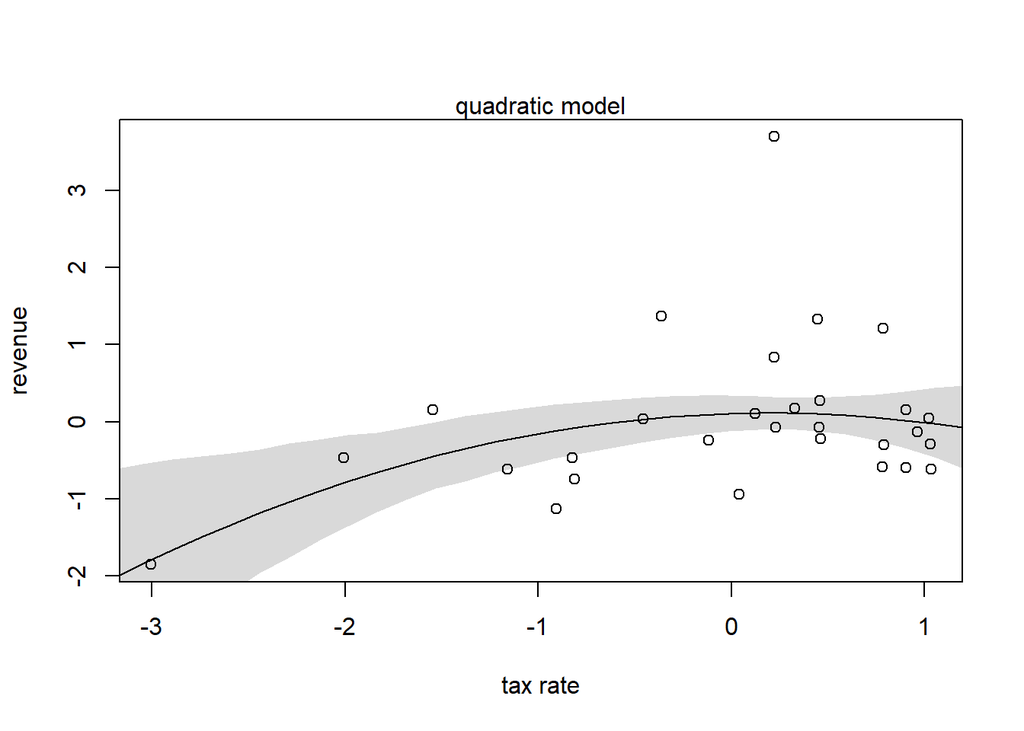

```r
T_seq <- seq( from=-3.2 , to=1.2 , length.out=30 )
#l_lin <- link( m7H1_lin , data=list(T=T_seq) )
l_quad <- link( m7H1_quad , data=list(T=T_seq) )
#l_cub <- link( m7H1_cub , data=list(T=T_seq) )
plot( d$T , d$R , xlab="tax rate" , ylab="revenue" )
mtext( "quadratic model" )
lines( T_seq , colMeans(l_quad) )
shade( apply( l_quad , 2 , PI ) , T_seq )
```

```r
## Run plots for the other models too
```

We should remember these are standardized variables.

Let’s now try a so-called robust model using the Student-t distribution for the response variable.

- Why might we think the Student-t is *robust*?

We will make the tails of the outcome nice and thick. To do this, we use the degrees of freedom parameter $\nu = 2$. This parameter derives from the definition of the student-t distribution with a Gaussian distribution in the numerator and a (square root of) chi-squared in the denominator with degrees of freedom.

```r
# linear model with student-t
m7H1_robust <- quap(
  alist(
    R ~ dstudent( 2 , mu , sigma ),
    mu <- a + b*T,
    a ~ dnorm( 0 , 0.2 ),
    b ~ dnorm( 0 , 0.5 ),
    sigma ~ dexp(1)
) , data=d )
precis( m7H1_robust )
```

```
##             mean         sd         5.5%       94.5%
## a     -0.1720475 0.09536457 -0.324458502 -0.01963649
## b      0.1920462 0.12338475 -0.005146485  0.38923885
## sigma  0.4443377 0.09480661  0.292818397  0.59585696
```

Comparing the previous models:

```r
compare( m7H1_lin , m7H1_quad , m7H1_cub , m7H1_robust , func=PSIS )
```

```
##                 PSIS       SE    dPSIS      dSE     pPSIS       weight
## m7H1_robust 74.34164 13.74169  0.00000       NA  3.737099 9.998070e-01
## m7H1_quad   91.98784 28.36473 17.64620 19.74669  8.599956 1.472629e-04
## m7H1_lin    94.51527 28.01774 20.17362 19.35051  8.852881 4.161685e-05
## m7H1_cub    99.14264 33.88627 24.80100 24.93470 12.269160 4.115739e-06
```

- Any winners?